# Projet 5 Parcours DAn V1 : Production d'etude de marché

# # Partitionnement de l'echantillon et clustering

```python
# Coupure du dendrogramme en 05 clusters
clusters = fcluster(Z, 5, criterion='maxclust')
print(clusters)
```

```
[2 4 3 4 3 1 5 4 3 5 3 3 4 5 2 5 3 2 5 3 2 5 5 2 5 2 2 2 2 3 5 4 5 5 2 5 5
 5 2 3 2 5 5 3 3 2 5 3 3 3 1 2 2 5 3 2 2 2 5 5 2 2 5 2 5 4 2 3 3 3 3 5 5 1
 5 2 4 5 4 2 5 1 2 3 3 5 2 5 2 1 2 3 4 5 4 5 5 3 2 5 2 2 2 2 3 5 5 2 1 2 4
 2 5 5 5 3 5 3 5 3 5 3 3 2 5 3 2 5 2 2 2 5 5 5 5 2 5 2 5 5 2 2 5 5 3 2 2 2
 5 5 2 2 5 4 4 4 5 5 2 5 4 2 2 2 4 3 5 3 2 2]
```

```python
#Je transforme  le resultats  de  mon partitionnement  en un dataframe
#Cela va me permettre de visualiser  les pays en fonction des clusters auxquels  ils appartiennent
payscluster = pd.DataFrame({"cluster": clusters, "Zone": names})
payscluster.head()
```

|  | cluster | Zone |
| --- | --- | --- |
| 0 | 2 | Afghanistan |
| 1 | 4 | Afrique du Sud |
| 2 | 3 | Albanie |
| 3 | 4 | Algérie |
| 4 | 3 | Allemagne |

```python
#Exportons cette  table en csv
payscluster.to_csv("grouppays.csv", index = False)
#cette methode cree un fichier csv  donas  notre repertoire  courant
```

```python
#Pour  mieux carateriser  nos  groupes et les  pays  qui les composent
#Nous allons   chercher  les centroides de chaque cluster en  usant  de  k-means
#Il sera donc appliqué  à  notre echantillon d'origine
#Ainsi  nous allons fusionner  les tables  avant d'appliquer  le  k-means
DFmerge = pd.merge(DFv,payscluster,on='Zone',how='inner')
DFmerge.head()
```

|  | Zone | ratioprot | ratiocr | disponibilite par habitant prot(kg/an/hab) | Disponibilité alimentaire (Kcal/personne/jour) | cluster |
| --- | --- | --- | --- | --- | --- | --- |
| 0 | Afghanistan | 19.441441 | 21.667976 | 20.25750 | 2038.0 | 2 |
| 1 | Afrique du Sud | 42.716605 | 9.506215 | 30.79505 | 2895.0 | 4 |
| 2 | Albanie | 53.375983 | -9.139616 | 42.21955 | 3361.0 | 3 |
| 3 | Algérie | 26.922239 | 7.702510 | 33.51430 | 3321.0 | 4 |
| 4 | Allemagne | 60.893961 | 0.479892 | 38.37975 | 3554.0 | 3 |

Ce dataframe obtenu suite à la transformation du partitionnement de l'echantillonn en nous basant sur le dendrogramme , nous avons 5 groupes de pays qu'on pourrait classer de 1 à 5. Au sein donc des clusters , les pays representés ont des caracteristiques communes donc une inertie intra-classe faible. Mais pour mieux caracteriser nos clusters et les pays qui les composent , nous allons realiser un clustering de type k-means afin d'avoir les centroides qui permettront de qualifier les pays "moyens" dans chaque groupe .

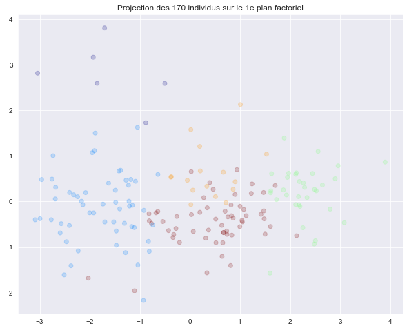

```python
#Nombre de clusters demande  = 5
n_clust = 5
#Selection des données  à prendre en compte  pour  l'ACP
X = DFmerge[['ratioprot','ratiocr','disponibilite par habitant prot(kg/an/hab)','Disponibilité alimentaire (Kcal/personne/jour)']].values
names = DFmerge['Zone'].to_numpy()

# Centrage et Réduction
std_scale = preprocessing.StandardScaler().fit(X)
X_scaled = std_scale.transform(X)

# Affichage du clustering par projection des individus sur le premier plan factoriel
pca = decomposition.PCA(n_components=4).fit(X_scaled)
X_projected = pca.transform(X_scaled)

# Clustering par K-means
km = KMeans(n_clusters=n_clust)
km.fit(X_projected)

# Récupération des clusters attribués à chaque individu
clusters =DFmerge['cluster'].values

plt.figure(figsize=(10,8))
plt.scatter(X_projected[:, 0], X_projected[:, 1], c=clusters.astype(np.float), cmap = 'jet', alpha=.2)
plt.title("Projection des {} individus sur le 1e plan factoriel".format(X_projected.shape[0]))
plt.savefig('projection des  individus sur  le  premier  plan factoriel.jpg')
plt.show(block=False)
```